# MScA, Financial Analytics (32001)

Yuri Balasanov, A. Doynikov, © iLykei, 2015

## Week 5: Workshop: Regression with Autocorrelated Residuals and Cointegration

### Regression models with autocorrelated errors

Read the data from file `WGS1_3YR.csv`

```r
x<-read.csv(file=paste(datapath,"WGS1_3YR.csv",sep="/"), header = TRUE)
r1 <- x[,2]
r3 <- x[,3]
```

$r_1=x_{t1}$ - the 1-year treasury constant maturity rate,  
$r_3=x_{t3}$ - the 3-year treasury constant maturity rate, $t=1,2,......T$

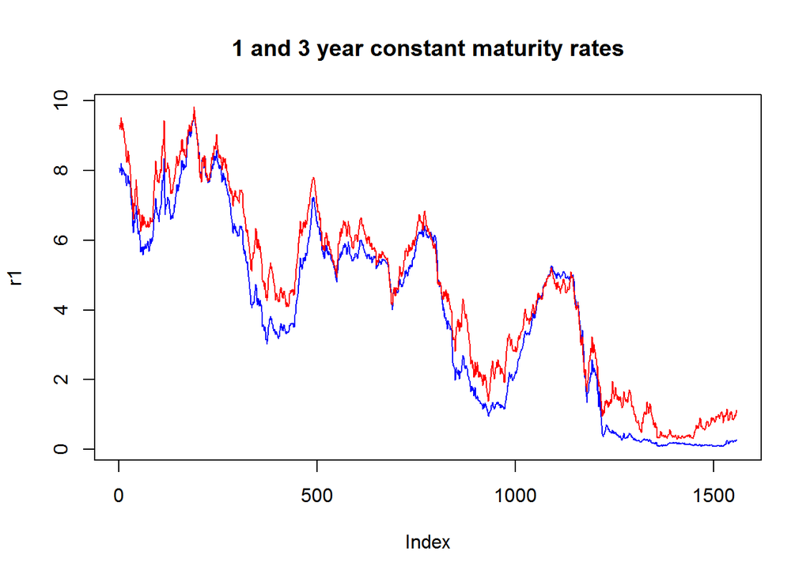

```r
plot(r1,col ="blue",type="l",main = "1 and 3 year constant maturity rates")
lines(r3,col="red",main = "1 and 3 year constant maturity rates")
```

Make the scatter plot of $x_{t1}$ and $x_{t3}$ to observe the level of correlation between the variables.

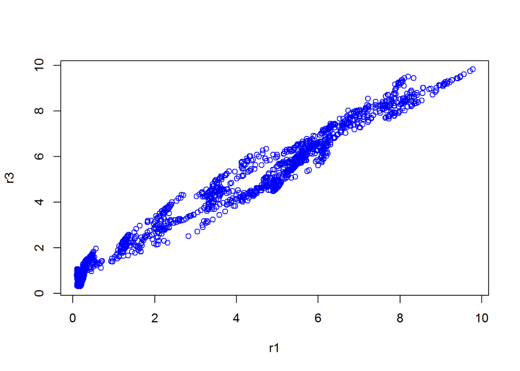

```r
r1<-as.vector(r1)
r3<-as.vector(r3)
plot(r1,r3,col= "blue")
```

**What do you conclude about applicability of linear model to these data?**

Describe the relationship between the two series by a simple regression model

$x_{t3}=\alpha + \beta_1 x_{t1}+\epsilon_{t1}$ $,t=1,2,......T$

See the results of the fit and interpret them.

Check the quality of the residuals.

```r
linreg <-lm(r3~r1)
summary(linreg)
```

```
##
## Call:
## lm(formula = r3 ~ r1)
##
## Residuals:
##      Min       1Q   Median       3Q      Max
## -0.96248 -0.32775  0.00115  0.31355  1.14522
##
## Coefficients:
##             Estimate Std. Error t value Pr(>|t|)
## (Intercept) 0.712700   0.019149   37.22   <2e-16 ***
## r1          0.963445   0.004039  238.55   <2e-16 ***
## ---
## Signif. codes:  0 '***' 0.001 '**' 0.01 '*' 0.05 '.' 0.1 ' ' 1
##
## Residual standard error: 0.4229 on 1555 degrees of freedom
## Multiple R-squared:  0.9734, Adjusted R-squared:  0.9734
## F-statistic: 5.691e+04 on 1 and 1555 DF,  p-value: < 2.2e-16
```

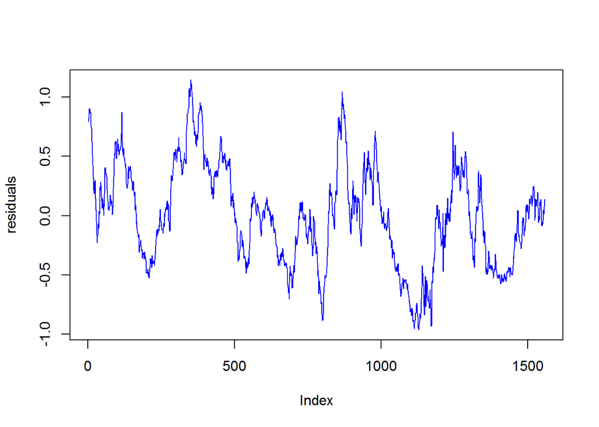

```r
residuals <- linreg$residuals
plot(residuals,type="l",col ="blue")
```

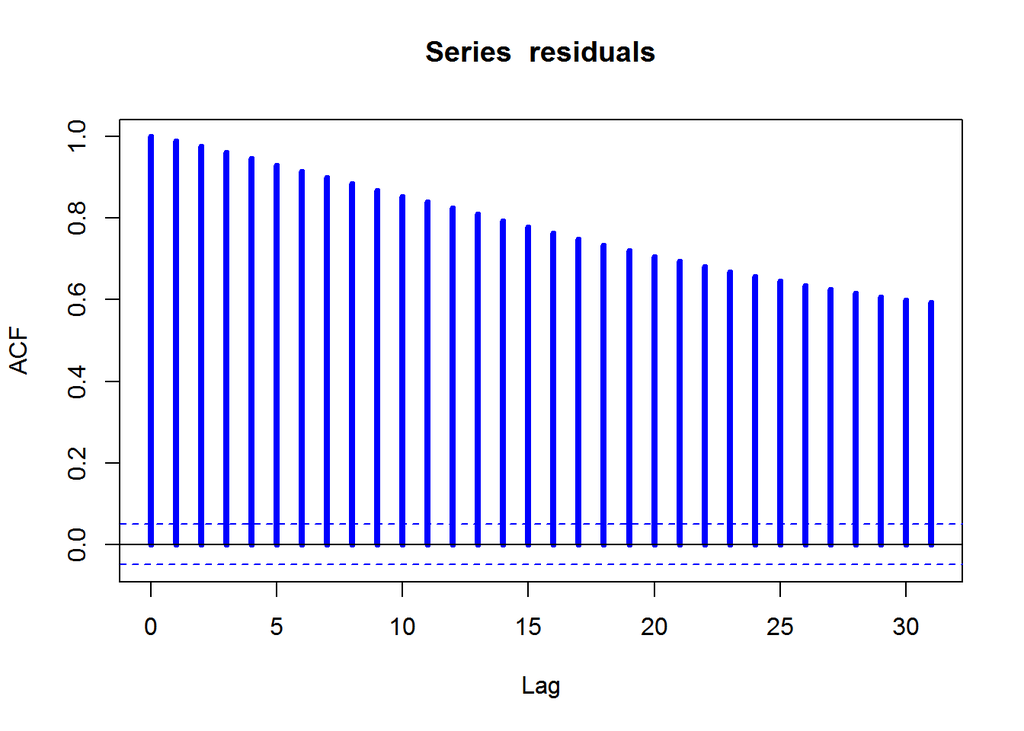

```r
acf(residuals,col ="blue",lty=1 ,lwd = 4)
```

```r
Box.test.residuals<-Box.test(residuals,lag=10,type='Ljung')
Box.test.residuals
```

```
##
##  Box-Ljung test
##
## data:  residuals
## X-squared = 13337, df = 10, p-value < 2.2e-16
```

The sample ACF of residuals is highly significant and decays slowly, showing that the process of the residuals has long memory and is not stationary.  
There is a pattern of a unit-root nonstationary time series, in other words two interest rates are not cointegrated.

This behavior of residuals leads to the consideration of differencing the series of interest rates.  
Let $c_{t1}= x_{t1}-x_{t-1,1}, c_{t3}= x_{t3}-x_{t-1,3}, t=2,\ldots.T$ be the differences of the 1-year and 3-year interest rates.

Consider linear regression $c_{3,t}= \beta_2 c_{t1}+\epsilon_{t2}, t=2,\ldots ,T$

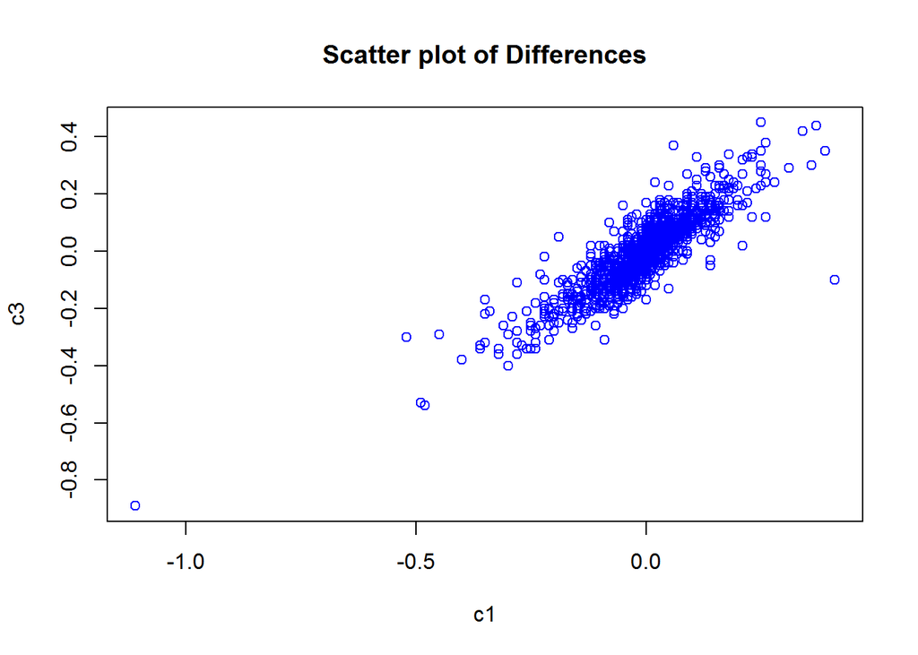

```r
c1<-diff(r1)
c3<-diff(r3)
plot(c1,c3,main="Scatter plot of Differences", col = "blue")
```

The figure shows that the differenced series remain highly correlated.

Fit linear regression to the differenced time series.

```r
clinreg <-lm(c3~c1-1)
summary(clinreg)
```

```
##
## Call:
## lm(formula = c3 ~ c1 - 1)
##
## Residuals:
##      Min       1Q   Median       3Q      Max
## -0.52005 -0.03098 -0.00172  0.02975  0.30853
##
## Coefficients:
##    Estimate Std. Error t value Pr(>|t|)
## c1  1.02451    0.01493    68.6   <2e-16 ***
## ---
## Signif. codes:  0 '***' 0.001 '**' 0.01 '*' 0.05 '.' 0.1 ' ' 1
##
## Residual standard error: 0.05779 on 1555 degrees of freedom
## Multiple R-squared:  0.7516, Adjusted R-squared:  0.7515
## F-statistic:  4706 on 1 and 1555 DF,  p-value: < 2.2e-16
```

```r
cresiduals <- clinreg$residuals
```

Test the residuals of `clinreg`.

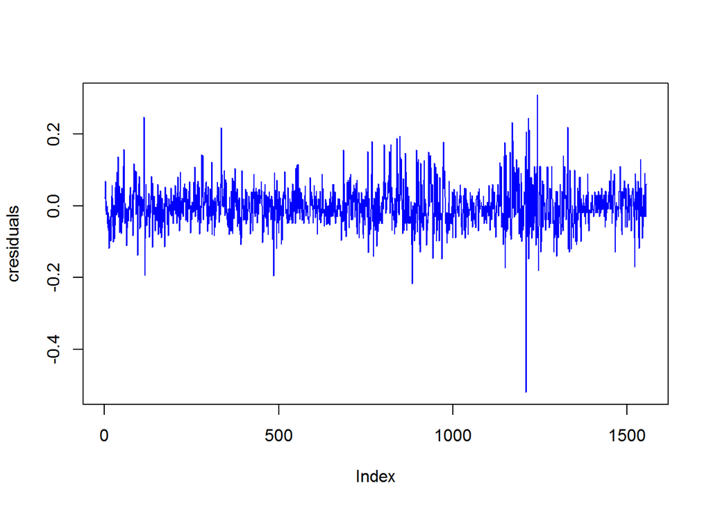

```r
plot(cresiduals,type ="l",col = "blue")
```

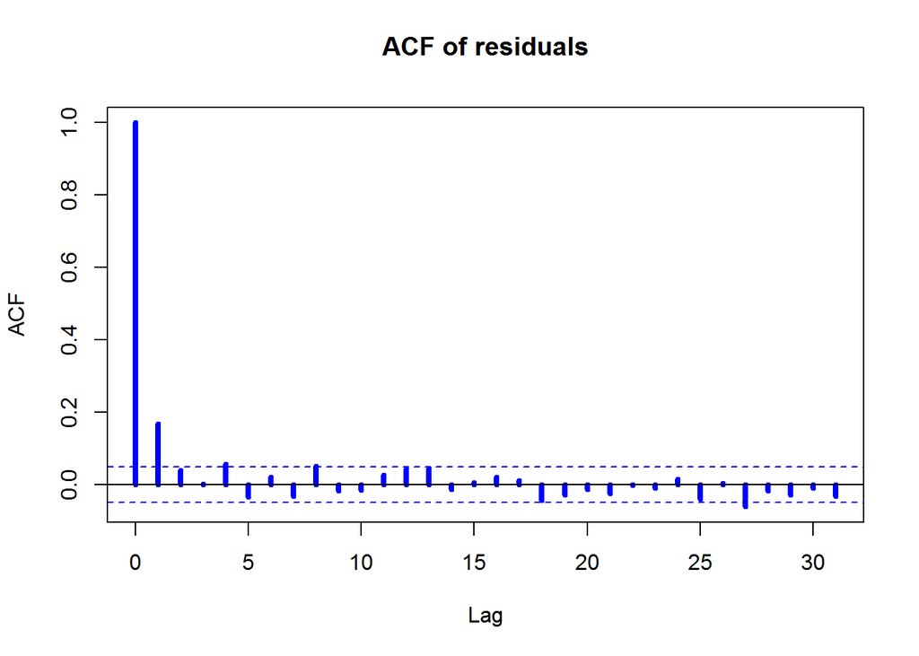

```r
acf(cresiduals,main = "ACF of residuals",col ="blue",lty=1 ,lwd = 4)
```

```r
Box.test.cresiduals<-Box.test(cresiduals,lag=10,type='Ljung')
Box.test.cresiduals
```

```
##
##  Box-Ljung test
##
## data:  cresiduals
## X-squared = 60.002, df = 10, p-value = 3.621e-09
```

The residuals from the fit to the differenced time series look close to stationary now.  
However, Box-Ljung test shows that serial correlation is still present.

From the sample ACF of residuals, we can identify an MA(1) model for the residuals and modify the linear regression model to $c_{t3}= \beta_2 c_{t1}+\epsilon_{t}$ $\epsilon_{t}= a_t-\theta_1a_{t-1},t=2,\ldots,T,$ where $a_t$ assumed to be a white noise series.

Estimate MA(1) model and explore the residuals.

```r
suppressWarnings(library(fArma))
ma1 <- armaFit(~ arma(0, 1), data = cresiduals)
summary(ma1, which =  "all")
```

```
##
## Title:
##  ARIMA Modelling
##
## Call:
##  armaFit(formula = ~arma(0, 1), data = cresiduals)
##
## Model:
##  ARIMA(0,0,1) with method: CSS-ML
##
## Coefficient(s):
##        ma1   intercept
##  0.1576619  -0.0001134
##
## Residuals:
##       Min        1Q    Median        3Q       Max
## -0.535503 -0.032129 -0.003149  0.031209  0.293120
##
## Moments:
## Skewness Kurtosis
## -0.01862  6.74808
##
## Coefficient(s):
##             Estimate  Std. Error  t value Pr(>|t|)
## ma1        0.1576619   0.0238446    6.612 3.79e-11 ***
## intercept -0.0001134   0.0016731   -0.068    0.946
## ---
## Signif. codes:  0 '***' 0.001 '**' 0.01 '*' 0.05 '.' 0.1 ' ' 1
##
## sigma^2 estimated as: 0.00325
## log likelihood:       2249.4
## AIC Criterion:        -4492.79
```

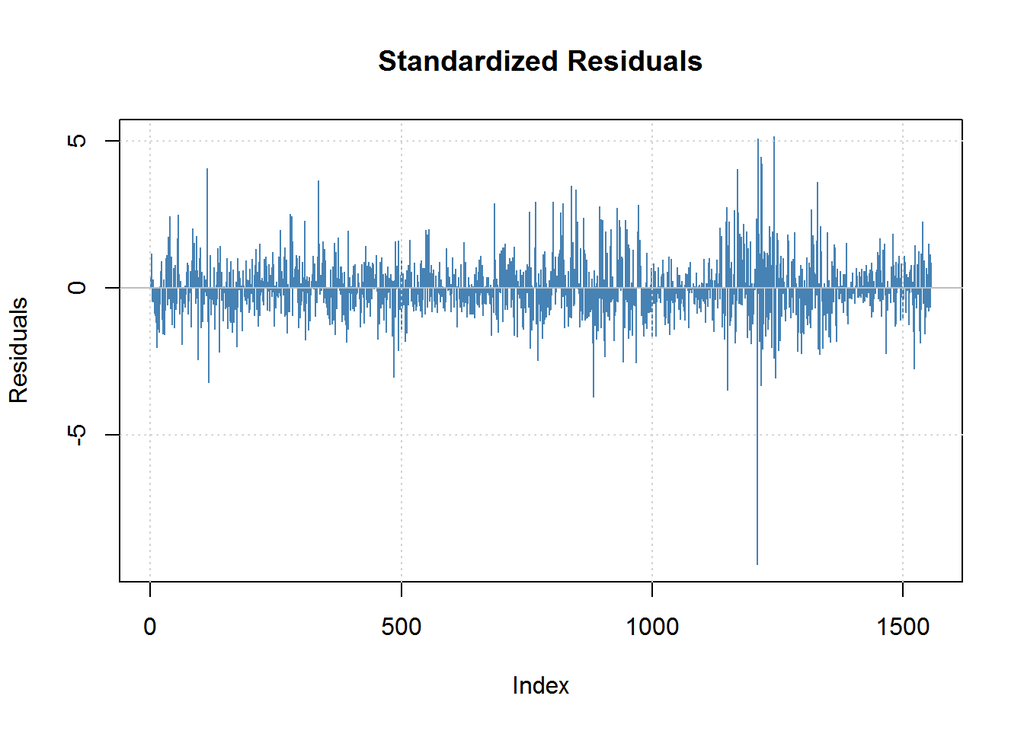

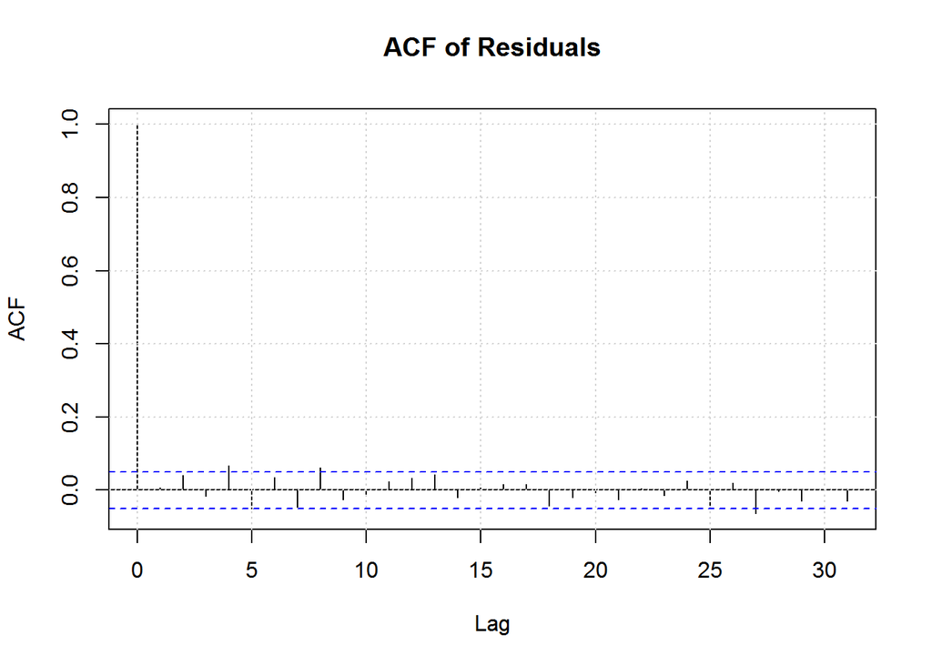

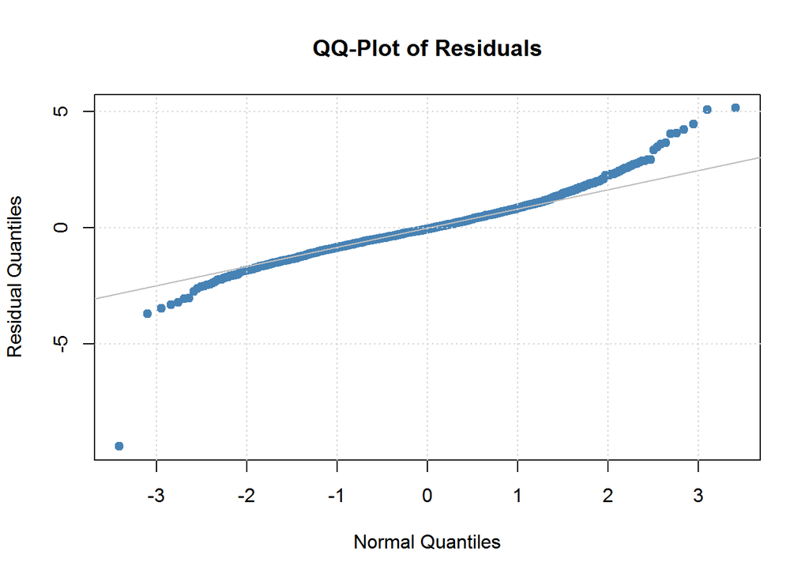

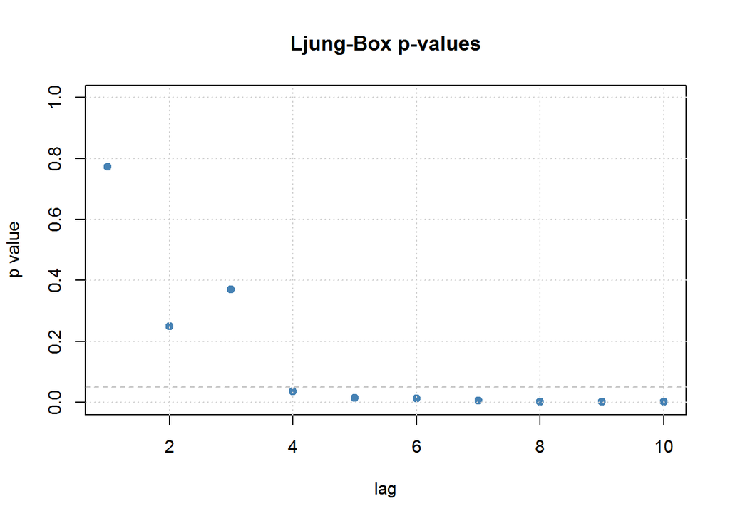

```
##
## Description:
##  Thu Jul 21 14:31:15 2016 by user: YURI
```

```r
ma1_res <- residuals(ma1)
```

Finally, we estimated a model for two weekly constant maturity interest rate series $x_{t,3}= x_{t-1,3} + \beta_2 (x_{t,1}-x_{t-1,1}) +\epsilon_{t}, t=2,\ldots,T,$ $\epsilon_{t}= a_t-\theta_1 a_{t-1}, t=2,\ldots,T.$

Build forecast for $r_3$ rate according this model.

First, find forecast for $\epsilon_{t}$ ,$t=2,\ldots,T$, using MA(1) model: $\epsilon_{t} = -\theta \epsilon_{t-1} = -\theta ResidualMA(1)_{t-1}.$  
Note that our notations are the same as in the book, but `arma()` uses MA coefficients with opposite signs: $\xi_t = a_t + \theta a_{t-1}.$

```r
theta1 <-ma1@fit$coef[1]
a_t <- theta1 *ma1_res
```

Let $f_t$ be a one-step forecast for $r_{t,3}$ $f_t= x_{t-1,3}+\beta_2 (x_{t,1}-x_{t-1,1})+\epsilon_t, t=2,\ldots,T.$

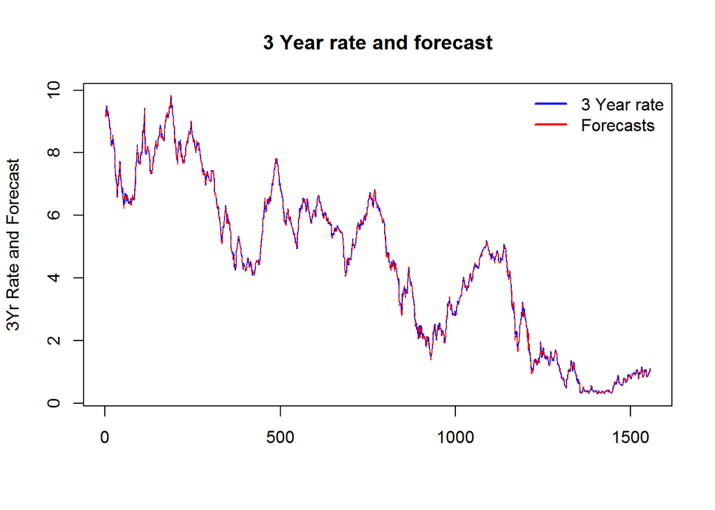

```r
x_1<-r3[-length(r3)]
forec <- x_1 + clinreg$coefficients*c1+a_t
matplot(cbind(r3[-1],forec),type = "l",col = c("blue","red"),main= "3 Year rate and forecast",ylab="3Yr Rate and Forecast")
legend("topright", c("3 Year rate","Forecasts"), lwd=2,col = c("blue","red"), bty="n")
```

But check the scatter plot of 3 year forecast differences versus differences of 1 year rate.

Let $\Delta f_t= f_t-f_{t-1}$ - be difference of $f_t,t=3,\ldots,T.$  
Plot $\Delta f_t$ against $\Delta r_1(t) = r_1(t)-r_1(t-1)$.

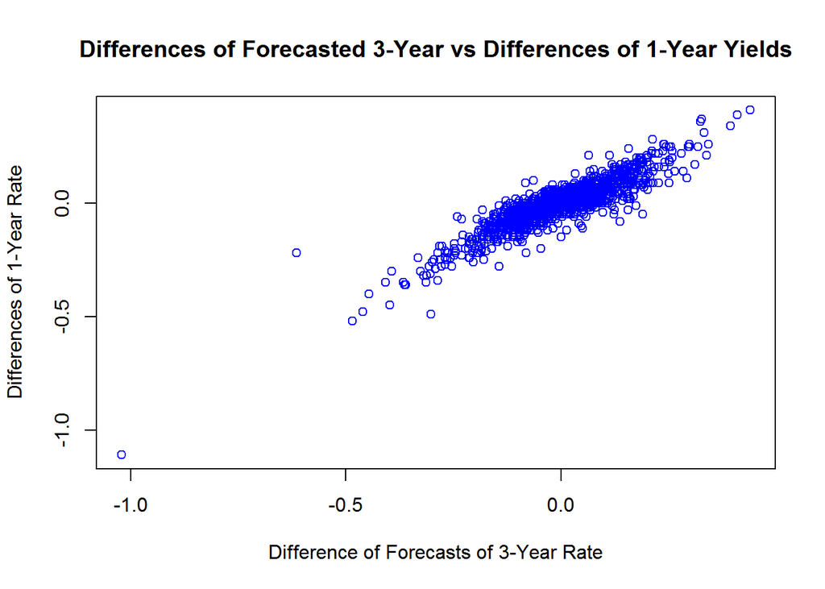

```r
difforec <- diff(forec)
cr<-cbind(difforec,c1[-1])
plot (cr[,1],cr[,2],col = "blue",main = "Differences of Forecasted 3-Year vs Differences of 1-Year Yields",
      xlab="Difference of Forecasts of 3-Year Rate",ylab="Differences of 1-Year Rate")
```

Figure shows that regression model with ARIMA residuals preserved the “short term” dependence of yields increments.

### Cointegration

In general, a (n,1) vector time series $x_t = <x_{t1},\ldots, x_{tn}>$ is said to be cointegrated if each of the series taken individually is unit-root nonstationary, while there exists some linear combination of the series $a^T x_t$ which is stationary for some nonzero vector $a$.

#### Interest Rates Example for the 900 Last Observations

Select a more recent and shorter period of last 900 observations of the data.

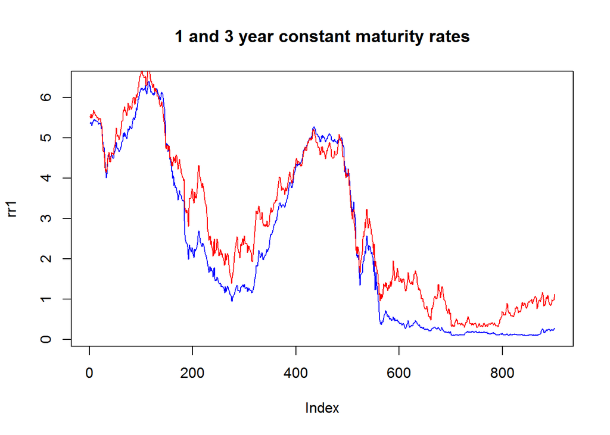

```r
n <- length(r1)
nb <-max(n-900,1)
rr1 <- r1[nb:n]
rr3 <- r3[nb:n]
plot(rr1,col ="blue",type="l",main = "1 and 3 year constant maturity rates")
lines(rr3,col="red")
```

Fit cointegration model

```r
suppressWarnings(library(urca))
```

```r
data <- cbind(rr1,rr3)
cajo <- ca.jo(data, ecdet = "none", type="eigen", K=2, spec="longrun")
summary(cajo)
```

```
##
## ######################
## # Johansen-Procedure #
## ######################
##
## Test type: maximal eigenvalue statistic (lambda max) , with linear trend
##
## Eigenvalues (lambda):
## [1] 0.016543728 0.001788635
##
## Values of teststatistic and critical values of test:
##
##           test 10pct  5pct  1pct
## r <= 1 |  1.61  6.50  8.18 11.65
## r = 0  | 15.00 12.91 14.90 19.19
##
## Eigenvectors, normalised to first column:
## (These are the cointegration relations)
##
##           rr1.l2     rr3.l2
## rr1.l2  1.000000 1.00000000
## rr3.l2 -1.127149 0.06602343
##
## Weights W:
## (This is the loading matrix)
##
##             rr1.l2       rr3.l2
## rr1.d -0.012890154 -0.001210571
## rr3.d  0.003401925 -0.001896343
```

Residuals and their ACF’s and PACF’s for 1 year and 3 year rate, respectively

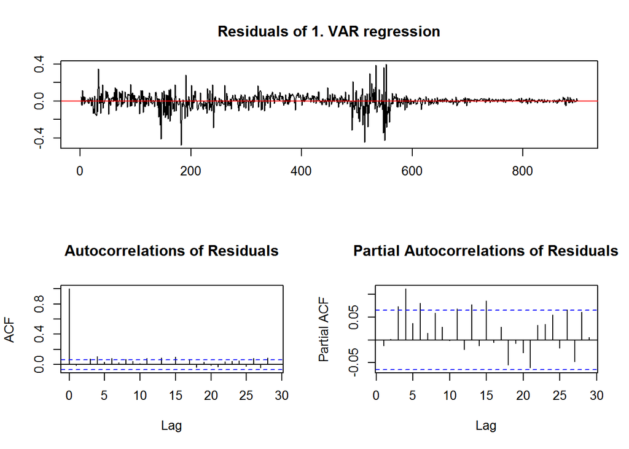

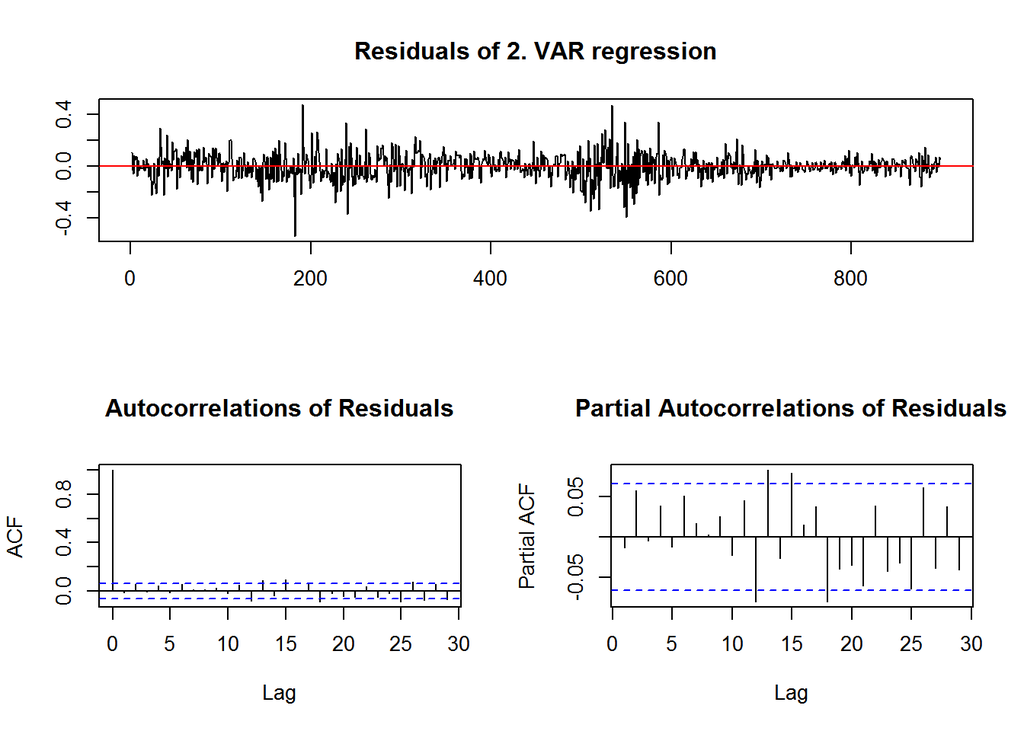

```r
plotres(cajo)
```

Check statistics and critical values of the test for cointegration order

```r
cajo@teststat
```

```
## [1]  1.609423 14.997211
```

```r
cajo@cval
```

```
##          10pct  5pct  1pct
## r <= 1 |  6.50  8.18 11.65
## r = 0  | 12.91 14.90 19.19
```

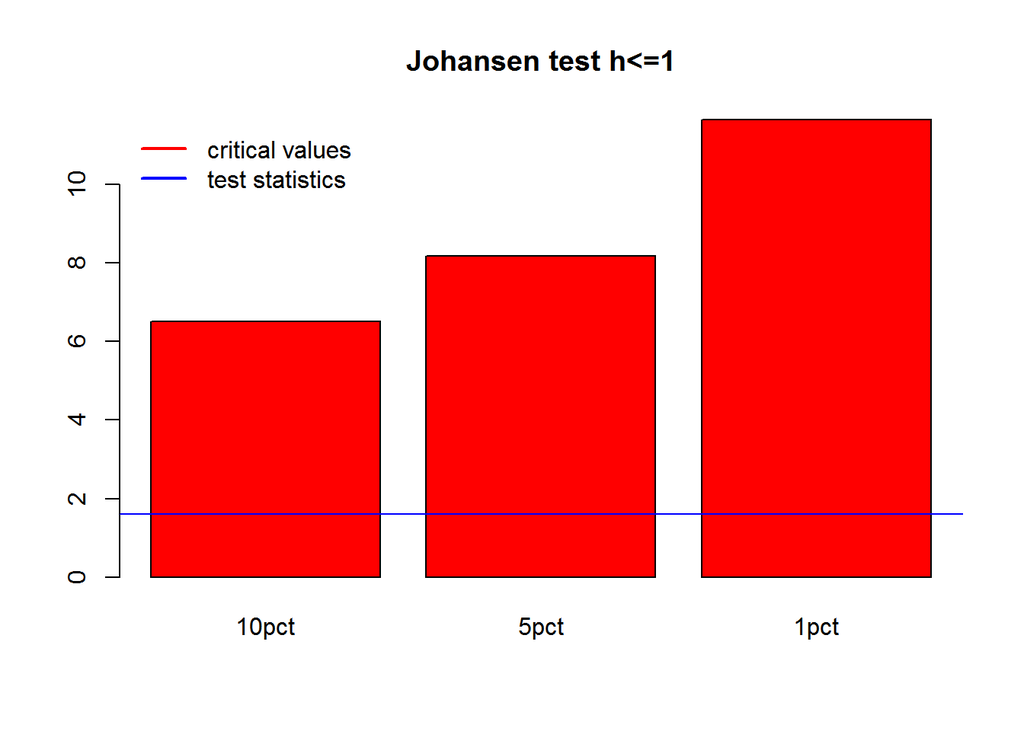

```r
barplot(cajo@cval[1,],main = "Johansen test h<=1",col = "red")
abline(h=cajo@teststat[1], col="blue")
legend("topleft", c("critical values","test statistics"), lwd=2,col = c("red","blue"), bty="n")
```

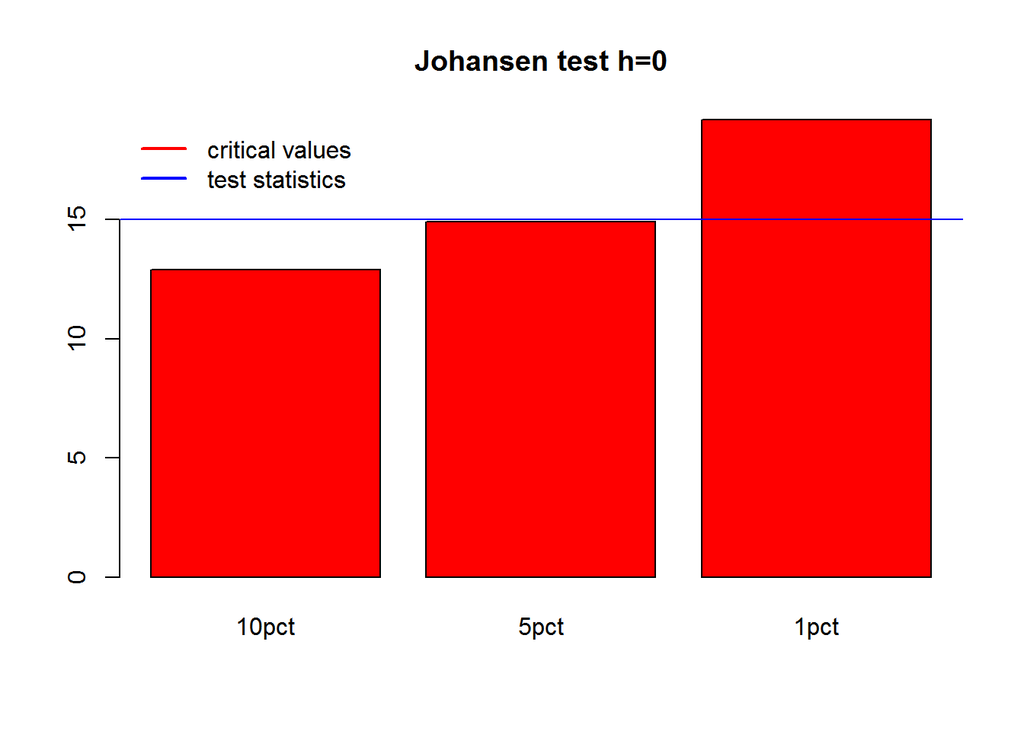

```r
barplot(cajo@cval[2,],main = "Johansen test h=0",col = "red")
abline(h=cajo@teststat[2], col="blue")
legend("topleft", c("critical values","test statistics"), lwd=2,col = c("red","blue"), bty="n")
```

The variable `cajo@cval` returns the critical values of the null hypothesis indicated in the output table of the variable and on the titles of the barplots.

If the test statistic is greater than the corresponding critical value the null hypothesis is rejected with that confidence.

For example, the first chart shows the critical values and test statistic for $H_0:~h \leq 1$, where $h$ is the order of cointegration.  
For all levels of 10%, 5%, 1% the statistic is below the critical values.  
So, $H_0:~r \leq 1$ cannot be rejected.

The second chart shows the same variables, but for $H_0:~h = 0$.  
For this null hypothesis the test statistic is above the critical values for 10% and for 5%.  
So, with levels of 5% or more $H_0:~h = 0$ is rejected.

**Conclusion: the cointegrating order equals 1.**

Cointegration vector $a_1=(a_{1,1},a_{1,2})$, normalized with respect to the first variable.

```r
(a_1<- cajo@V[,1])
```

```
##    rr1.l2    rr3.l2
##  1.000000 -1.127149
```

By definition of cointegration with order $h=1$ process $z_{t,1}=a_1^T~x_t$ must be stationary ($I(0)$).

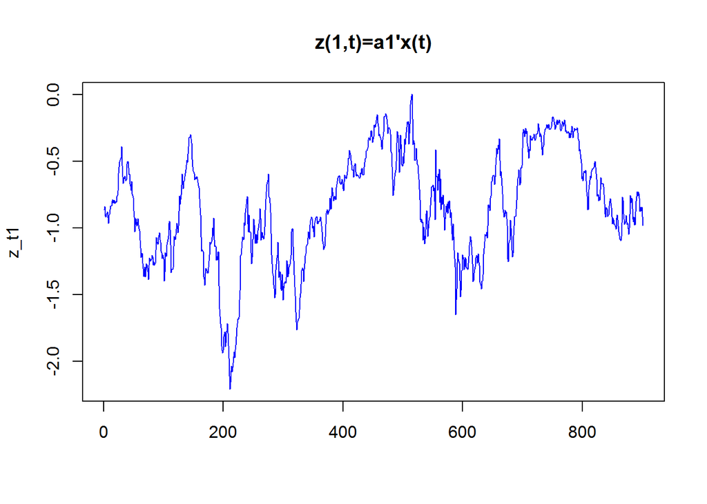

```r
z_t1= data %*% a_1
matplot(z_t1,type ="l", main = "z(1,t)=a1'x(t)", col = "blue")
```

Estimate autoregression model for process $z_{t,1}$

```r
zar <-ar(z_t1,  aic = TRUE,method = "yule-walker")
zar$order
```

```
## [1] 6
```

The order of the AR process is chosen by R using the Akaike Information Criterion (AIC)

Check the roots of characteristic equation.

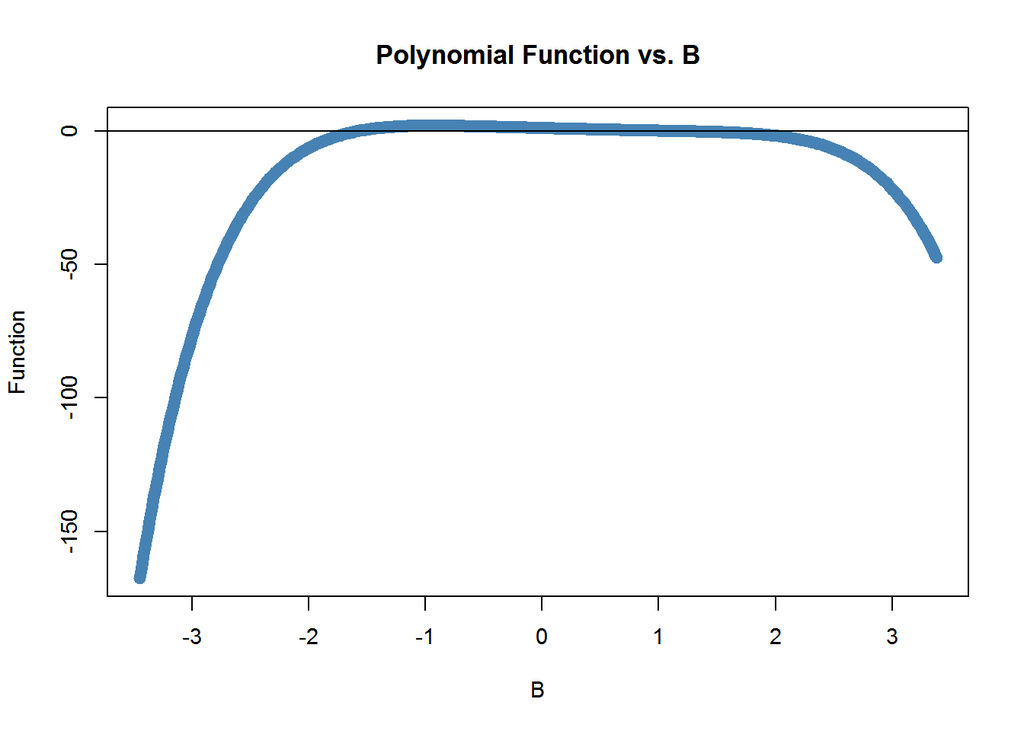

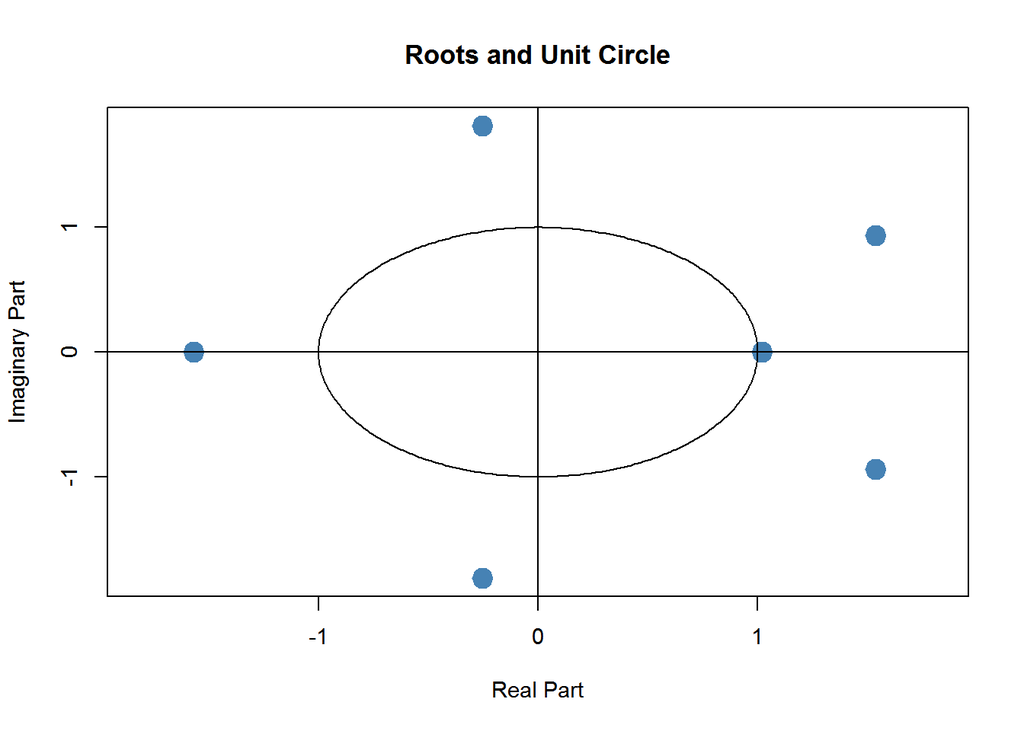

```
##           re         im     dist
## 1  1.0210936  0.0000000 1.021094
## 2 -1.5673787  0.0000000 1.567379
## 3 -0.2550661 -1.8147755 1.832613
## 4  1.5364903 -0.9372609 1.799795
## 5  1.5364903  0.9372609 1.799795
## 6 -0.2550661  1.8147755 1.832613
```

```r
par(mfrow = c(1, 1), cex = 0.9)
armaRoots(zar$ar,lwd = 8, n.plot = 400, digits = 8)
```

Since cointegration order equals 1, vector $a_2=(a_{2,1},a_{2,2})$ is not a cointegration vector and the process $z_{t,2}=a_2'x_t$ is not stationary.

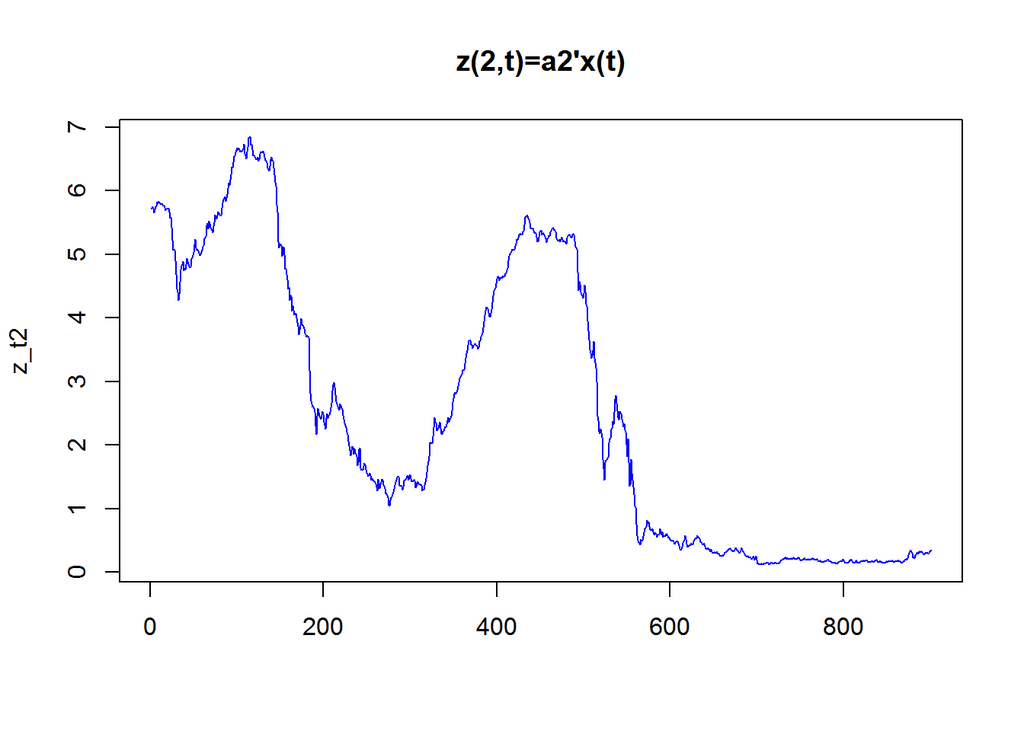

```r
a_2<- cajo@V[,2]
z_t2= data %*% a_2
matplot(z_t2,type ="l", main = "z(2,t)=a2'x(t)", col = "blue")
```

#### Predicting Using Cointegration Model

Suppose that $X_t$ can be represented as a unit-root nonstationary two-dimensional ($n=2$) vector AR(2) model:

$x_{t,1}= \pi_{1,1}^{(1)} x_{t-1,1} + \pi_{1,2}^{(1)} x_{t-1,2}+\pi_{1,1}^{(2)} x_{t-2,1} + \pi_{1,2}^{(2)} x_{t-2,2} + \mu_1 + \epsilon_{t,1},$ $x_{t,2}= \pi_{2,1}^{(1)} x_{t-1,1} + \pi_{2,2}^{(1)} x_{t-1,2}+\pi_{2,1}^{(2)} x_{t-2,1} + \pi_{2,2}^{(2)} x_{t-2,2} + \mu_2 + \epsilon_{t,2},$ $t = 3,\ldots,T.$

where $E[\epsilon_{t,1}]=E[\epsilon_{t,2}]=0,$ $E[\epsilon_{t,1} \epsilon_{t,2}] = 0,$ $E[\epsilon_{t,1}^2] =\sigma_1^2, E[\epsilon_{t,2}^2] =\sigma_2^2.$

Subtract vector $(x_{t-1,1},x_{t-1,2})^t$ from the equations to obtain  
$x_{t,1}-x_{t-1,1}= (\pi_{1,1}^{(1)}-1) x_{t-1,1} + \pi_{1,2}^{(1)} x_{t-1,2}+\pi_{1,1}^{(2)} x_{t-2,1} + \pi_{1,2}^{(2)} x_{t-2,2} + \mu_1 + \epsilon_{t,1},$ $x_{t,2}-x_{t-1,2}= \pi_{2,1}^{(1)} x_{t-1,1} + (\pi_{2,2}^{(1)}-1) x_{t-1,2}+\pi_{2,1}^{(2)} x_{t-2,1} + \pi_{2,2}^{(2)} x_{t-2,2} + \mu_2 + \epsilon_{t,2},$ $t = 3,\ldots,T.$

Rewrite it in matrix form

$\Delta X_t=\Gamma X_{t-1}+\Pi X_{t-2}+\mu+\epsilon_t$ $t = 3,\ldots,T.$

Equivalently, $\Delta X_t= \Gamma X_{t-1}-\Gamma X_{t-2}+ \Gamma X_{t-2} + \Pi_2 X_{t-2}+\mu+\epsilon_t$ $= \Gamma \Delta X_{t-1} + (\Gamma + \Pi) X_{t-2}+\mu+\epsilon_t$ $= \Gamma \Delta X_{t-1} + \Pi_1 X_{t-2}+\mu+\epsilon_t,$ $\Pi_1 = \Gamma + \Pi,~ t = 3,\ldots,T.$

This is the form in which function `ca.jo()` fits the model with the setting `spec="longrun"`.  
This form also corresponds to the first specification in R documentation for `library(urca)`, method `ca.jo(...)`.

Correspondence to the slots names of the object `ca.jo`:

- `Gamma = cbind(mu,Gamma[,2:3])`, where `mu` is $\mu$ and `Gamma[,2:3]` is $\Gamma$
- `Pi` is $\Pi_1$

In order to forecast the fitted model do the following:

Vector $\mu$:

```r
(mu <-cajo@GAMMA[,1])
```

```
##        rr1.d        rr3.d
## -0.012005086  0.003871514
```

Matrix of coefficients $\Pi_1$ ( slot `PI` of class `ca.jo`)

```r
(PI<-cajo@PI)
```

```
##             rr1.l2       rr3.l2
## rr1.d -0.014100725  0.014449204
## rr3.d  0.001505582 -0.003959681
```

Matrix of coefficients $\Gamma$ (slot `GAMMA` of class `ca.jo`)

```r
(Gamma<-cajo@GAMMA[,2:3])
```

```
##           rr1.dl1    rr3.dl1
## rr1.d  0.18527518 0.09212221
## rr3.d -0.01290542 0.22996137
```

In order to construct forecasts we also need matrix $\Delta X_{t-1}$ and matrix $X_{t-2}$,$t = 3,\ldots,T$.

Matrix $\Delta X_{t-1},t = 3,\ldots,T$ (slot `Z0` of class `ca.jo`):

```r
dX_1 <- cajo@Z0
head(dX_1)
```

```
##      rr1.d rr3.d
## [1,]  0.03  0.09
## [2,] -0.03 -0.02
## [3,] -0.06 -0.07
## [4,]  0.09  0.06
## [5,]  0.01  0.05
## [6,]  0.05  0.08
```

Matrix $X_{t-2},t = 3,\ldots,T$ (slot `ZK` of class `ca.jo`):

```r
X_2 <- cajo@ZK
head(X_2)
```

```
##      rr1.l2 rr3.l2
## [1,]   5.37   5.53
## [2,]   5.36   5.50
## [3,]   5.39   5.59
## [4,]   5.36   5.57
## [5,]   5.30   5.50
## [6,]   5.39   5.56
```

We call time $t$ the forecast origin and $1$ is the forecast horizon.  
Denote the forecast itself as $\Delta \hat {X}_t(1)$.

Conditional expectation of the forecast $E[\Delta \hat {X}_t(1)|t]=\Gamma \Delta X_{t}+\Pi_1 X_{t-1}+\mu,~t = 3,\ldots,T.$

```r
deltaX_t_1 <- Gamma %*% t(dX_1) + PI %*%t(X_2)
deltaX_t_1<-apply(deltaX_t_1,2,"+",mu)
```

The forecasts for rates are $E[\hat {X}_t(1)|t]=E[X_t+\Delta \hat {X}_t(1)|t]= X_t+E[\Delta \hat {X}_t(1)|t]= X_t+\Gamma \Delta X_{t}+\Pi X_{t-1}+\mu,~t = 3,\ldots,T$

```r
nrowsdata <- dim(data)[1]
data_t_2 = data[3:nrowsdata,]
deltaX_t_1 <- t(deltaX_t_1)
forecX <- data_t_2+deltaX_t_1
```

Plot predictions of the 1-year yield

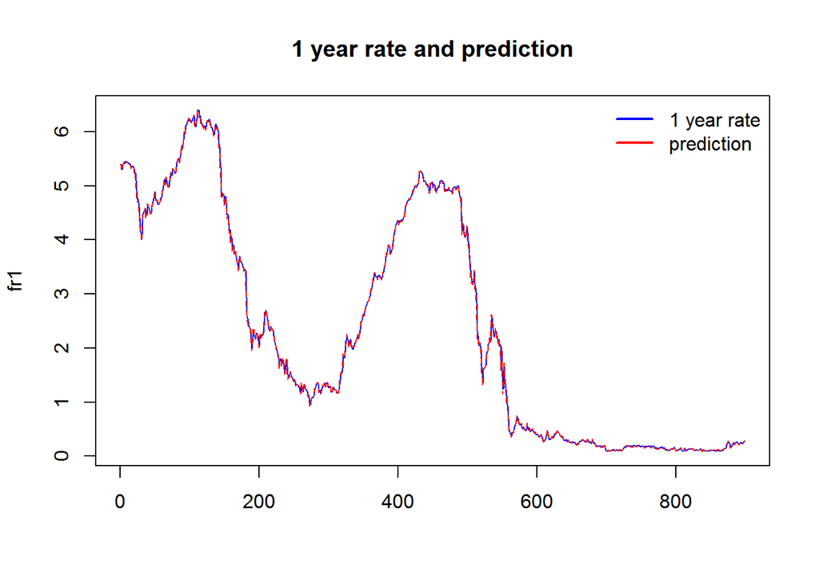

```r
fr1 = cbind(rr1[3:length(rr1)],forecX[,1])
matplot(fr1,col =c("blue","red"),type="l",main = "1 year rate and prediction")
legend("topright", c("1 year rate","prediction"), lwd=2,col = c("blue","red"), bty="n")
```

Plot predictions of 3-year yield.

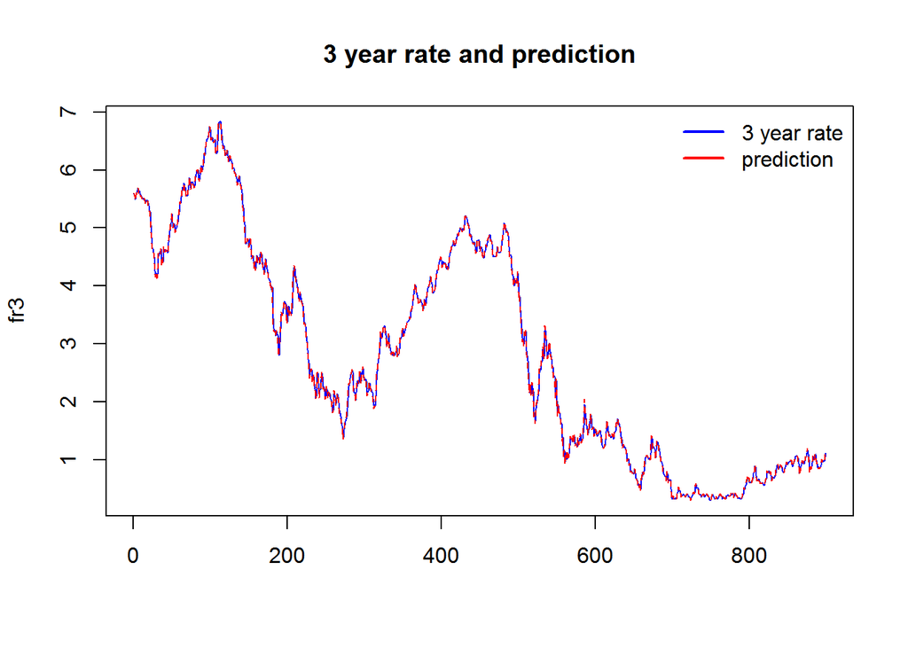

```r
fr3 = cbind(rr3[3:length(rr3)],forecX[,2])
matplot(fr3,col =c("blue","red"),type="l",main = "3 year rate and prediction")
legend("topright", c("3 year rate","prediction"), lwd=2,col = c("blue","red"), bty="n")
```

Figures show that cointegration model preserved long term dependence of 1- and 3- year rates.

Difference the forecasts and plot them.

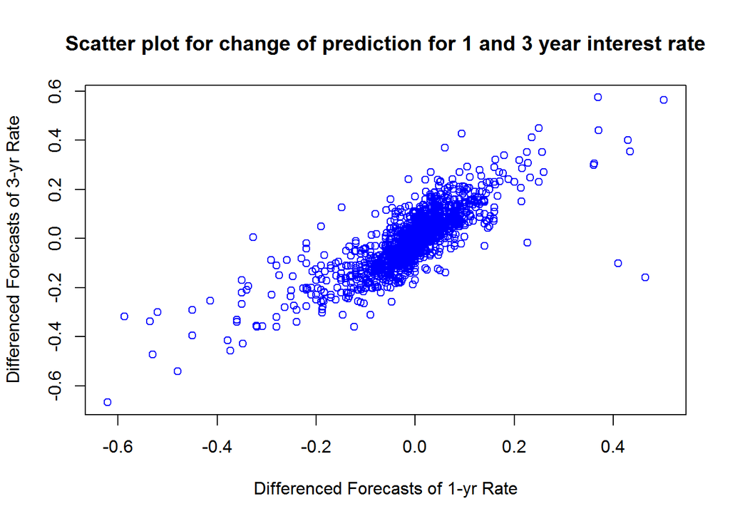

```r
dfr1 = diff(fr1)
dfr3 = diff(fr3)
plot(dfr1,dfr3,col ="blue",main = "Scatter plot for change of prediction for 1 and 3 year interest rate",
     xlab="Differenced Forecasts of 1-yr Rate",ylab="Differenced Forecasts of 3-yr Rate")
```

Figure shows that cointegration model also captured short term dependence of rates differences.

Cointegration model in contrast to the regression allows us predicting both 1 year and 3 year rate.

Check errors of prediction by the cointegration model.

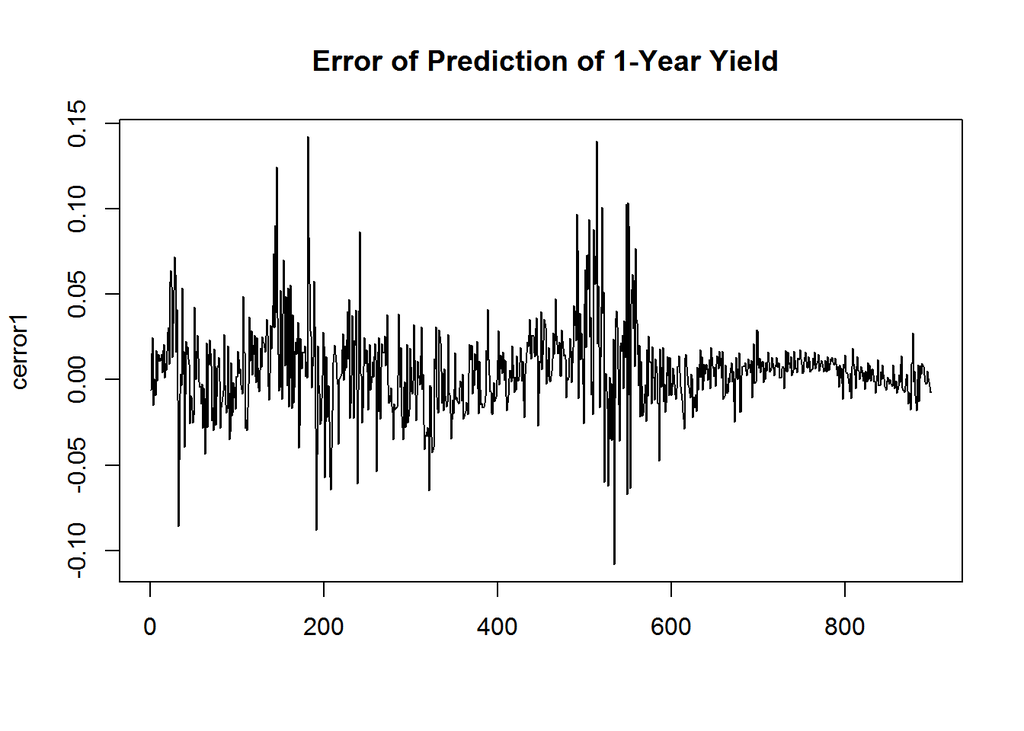

```r
cerror1<-rr1[3:length(rr1)]-forecX[,1]
cerror3<-rr3[3:length(rr1)]-forecX[,2]
matplot(cerror1,main = " Error of Prediction of 1-Year Yield",type = "l")
```

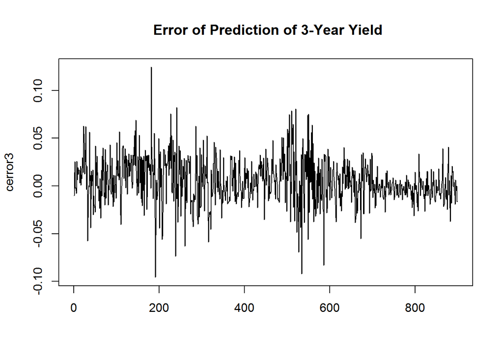

```r
matplot(cerror3,main = " Error of Prediction of 3-Year Yield",type = "l")
```

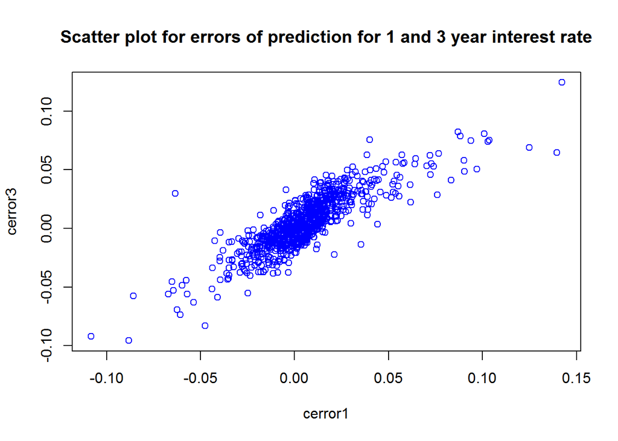

```r
plot(cerror1,cerror3,col ="blue",main = "Scatter plot for errors of prediction for 1 and 3 year interest rate")
```

```r
cor(cbind(cerror1,cerror3))
```

```
##           cerror1   cerror3
## cerror1 1.0000000 0.8506262
## cerror3 0.8506262 1.0000000
```

#### Regression model for the 900 last observations

All results have prefix _900 Repeat regression model with autocorrelated errors for last 900 observations

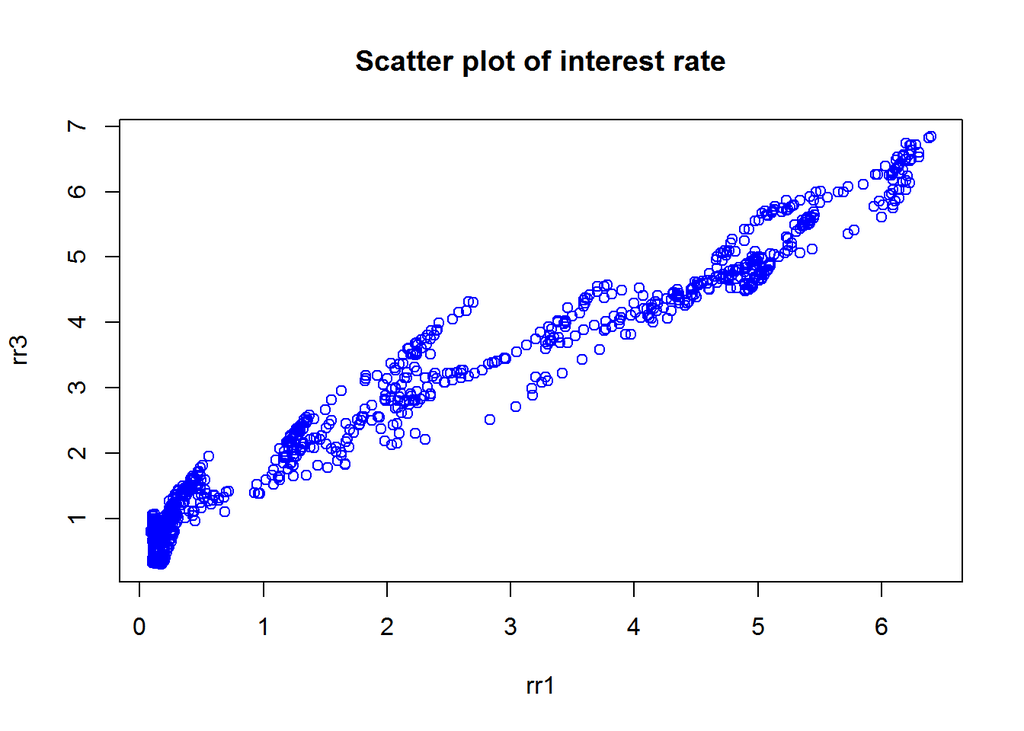

```r
plot(rr1,rr3,col= "blue", main = "Scatter plot of interest rate")
```

Describe the relationship between two series by the simple regression model

$x_{t3}=\alpha + \beta_1 x_{t1}+\epsilon_{t1}$ $,t=1,2,......T$

The fitted model

```r
linreg_900 <-lm(rr3~rr1)
summary(linreg_900)
```

```
##
## Call:
## lm(formula = rr3 ~ rr1)
##
## Residuals:
##      Min       1Q   Median       3Q      Max
## -0.75156 -0.26627  0.00488  0.23237  1.20889
##
## Coefficients:
##             Estimate Std. Error t value Pr(>|t|)
## (Intercept) 0.756962   0.018291   41.39   <2e-16 ***
## rr1         0.885018   0.005845  151.42   <2e-16 ***
## ---
## Signif. codes:  0 '***' 0.001 '**' 0.01 '*' 0.05 '.' 0.1 ' ' 1
##
## Residual standard error: 0.3657 on 899 degrees of freedom
## Multiple R-squared:  0.9623, Adjusted R-squared:  0.9622
## F-statistic: 2.293e+04 on 1 and 899 DF,  p-value: < 2.2e-16
```

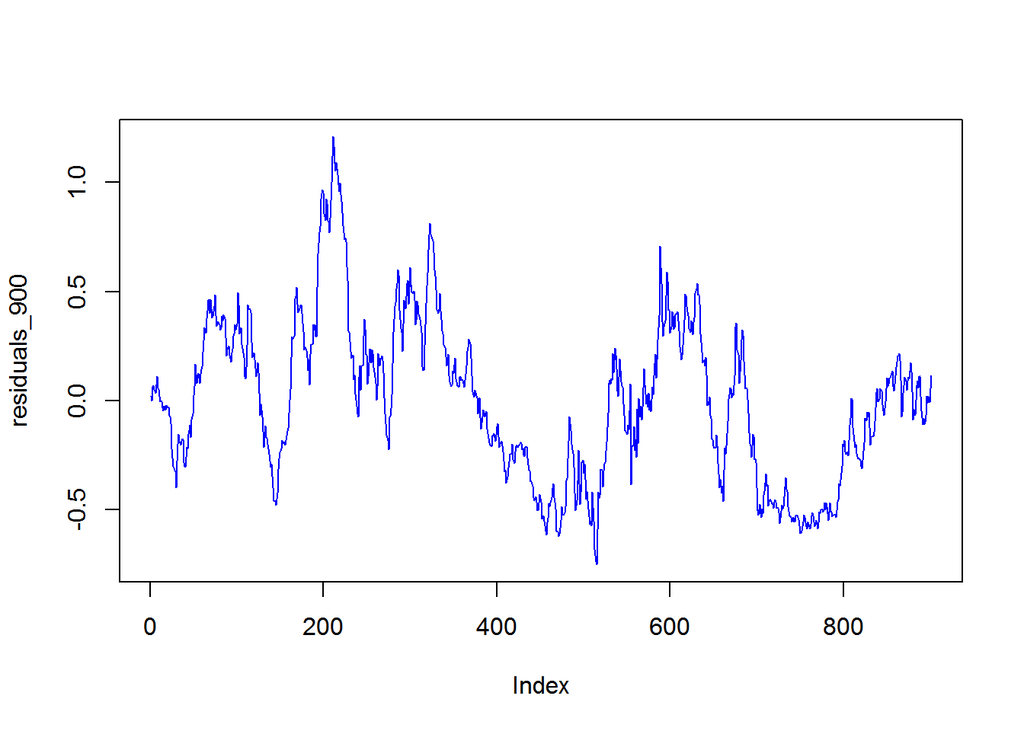

```r
residuals_900 <- linreg_900$residuals
plot(residuals_900,type="l",col ="blue")
```

The process for residuals is unit-root nonstationary

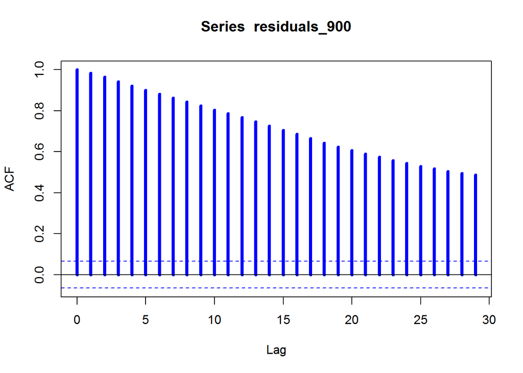

```r
acf(residuals_900,col ="blue",lty=1 ,lwd = 4)
```

The sample ACF of the residuals is highly significant and decays slowly, showing the pattern of a unit-root nonstationary time series in other words two interest rates are not cointegrated.